# College GPA vs Parental Education

```r
# From your file menu (at the top of R-Studio) select:
# "Session -> Set working directory -> To source file location"
# Then play this chunk to get the data into R.
library(mosaic)
library(car)
library(DT)
library(pander)
library(readr)
library(forcats)
food <- read_csv("../../Data/food.csv") #food.csv is in the Data folder...

food1 <- food %>%
  select(c(GPA, father_education, mother_education))
```

### Background

A survey was given to college students asking a series of questions. Among the questions included the education status of each of their parents. Here are the options from the survey:

1. less than high school
2. high school degree
3. some college degree
4. college degree
5. graduate degree

From that information, new groups have been created including the education of both parents combined:

- Both High school Dropouts (BHSD)
- At least one high school graduate (1HS)
- At least one did some college (1SC)
- At least one bachelors degree (1BD)
- At least one graduate degree (1GD)
- Both graduate degrees (BGD)

The table below represents how these groups are distinguished; where the axis are mother_education by father_education; the numbers 1-5 are correlated to the education status numbered above.

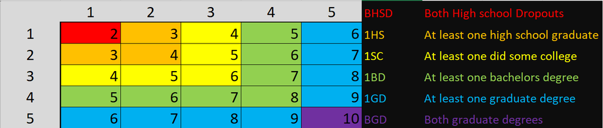

```r
food2 <- food1 %>%
  mutate(
    parent_education = case_when(
      mother_education == 1 & father_education == 1 ~
        "BHSD",
      mother_education %in% c(1,2) & father_education == 2 |
        mother_education == 2 & father_education == 1 ~
        "1HS",
      mother_education %in% c(1,2,3) & father_education == 3 |
        mother_education == 3 & father_education %in% c(1,2) ~
        "1SC",
      mother_education %in% c(1,2,3,4) & father_education == 4 |
        mother_education == 4 & father_education %in% c(1,2,3) ~
        "1BD",
      mother_education %in% c(1,2,3,4) & father_education == 5 |
        mother_education == 5 & father_education %in% c(1,2,3,4) ~
        "1GD",
      mother_education == 5 & father_education == 5 ~
        "BGD"
    ),
    GPA = as.numeric(GPA)
  ) %>%
  na.omit()

datatable(food2, options=list(lengthMenu = c(5,10,30)))
```

|  | GPA | father_education | mother_education | parent_education |
| --- | --- | --- | --- | --- |
| 1 | 2.4 | 5 | 1 | 1GD |
| 2 | 3.654 | 2 | 4 | 1BD |
| 3 | 3.3 | 2 | 2 | 1HS |
| 4 | 3.2 | 2 | 4 | 1BD |
| 5 | 3.5 | 4 | 5 | 1GD |
| 6 | 2.25 | 1 | 1 | BHSD |
| 7 | 3.8 | 4 | 4 | 1BD |
| 8 | 3.3 | 3 | 2 | 1SC |
| 9 | 3.3 | 5 | 5 | BGD |
| 10 | 3.3 | 5 | 5 | BGD |

[output cut: 107 more lines]

### Hypothesis

Sir Isaac Newton, a famous English scientist, once said, “If I have seen further, it is by standing on the shoulders of giants.” He felt that his success came because of the many scientists who came before him.

Does this principle apply to parents and their children? More specifically, do parents’ education levels have an impact their child’s GPA? Does the success of parents allow their children to build on their work and have a scholastic advantage?
$$H_0:
\text{All samples are from the same distribution.}$$
$$H_a: \text{At least one sample's distribution
is stochastically different.}$$
For this test, we will be using a significance level of $\alpha = 0.05$.

### Analysis

Lets take a look at our data:

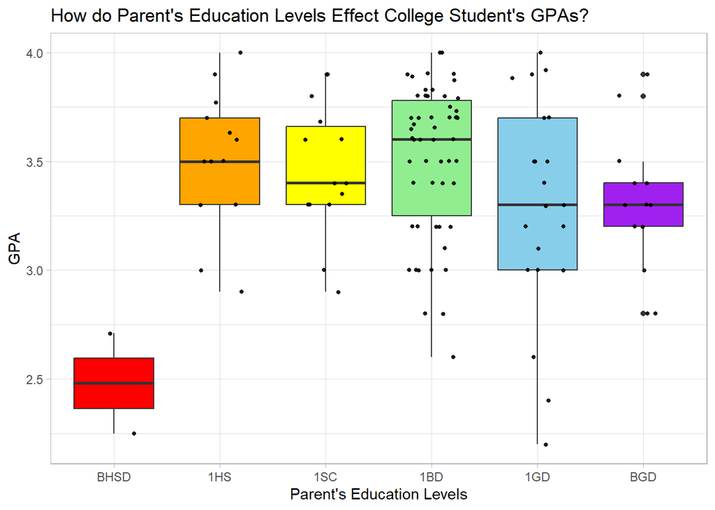

```r
food2 <- food2 %>%
  mutate(
    parent_education = fct_relevel(parent_education,
                                        "BHSD", "1HS", "1SC",
                                        "1BD", "1GD", "BGD")
  )

ggplot(food2, aes(x=parent_education, y=GPA)) +
  geom_boxplot(fill=c('red','orange','yellow','lightgreen','skyblue','purple')) +
  geom_jitter(color="black", size=1, alpha=0.9, width= 0.25) +
  labs(title= "How do Parent's Education Levels Effect College Student's GPAs?",
       x= "Parent's Education Levels") +
  theme_light()
```

There is a clear difference in the “Both high school dropout” group and the others. Lets see if this difference is significant with a Kruskal-Wallis Test:

```r
kruskal.test(GPA ~ parent_education, data=food2) %>%
  pander(caption="Kruskal-Wallis Rank Sum Test")
```

Kruskal-Wallis Rank Sum Test

| Test statistic | df | P value |
| --- | --- | --- |
| 11.91 | 5 | 0.03611 * |

With a p-value of 0.03611, it is clear that GPA is effected by parents’ education level. Lets compare the means of our data:

```r
favstats(GPA ~ parent_education, data=food2)[,-10] %>%
  pander(caption='Group Number Summary')
```

Group Number Summary

| parent_education | min | Q1 | median | Q3 | max | mean | sd | n |
| --- | --- | --- | --- | --- | --- | --- | --- | --- |
| BHSD | 2.25 | 2.365 | 2.48 | 2.595 | 2.71 | 2.48 | 0.3253 | 2 |
| 1HS | 2.9 | 3.3 | 3.5 | 3.7 | 4 | 3.508 | 0.3213 | 13 |
| 1SC | 2.9 | 3.3 | 3.4 | 3.66 | 3.9 | 3.459 | 0.3053 | 14 |
| 1BD | 2.6 | 3.25 | 3.603 | 3.78 | 4 | 3.516 | 0.3401 | 54 |
| 1GD | 2.2 | 3 | 3.3 | 3.7 | 4 | 3.3 | 0.4931 | 21 |
| BGD | 2.8 | 3.2 | 3.3 | 3.4 | 3.9 | 3.3 | 0.3266 | 13 |

There is a difference of more than one GPA between average GPA of the BHSD and 1BD groups (2.48 < 3.52).

### Conclusion

There is sufficient evidence to conclude the hypothesis the distribution of GPA is different for at least one parental education group. We can see that this difference is between the “Both high school dropout” group and one or more of the other groups. This tells us that parents’ educations have an impact on their child’s college GPA. Students are like Newton: We too “…[stand] on the shoulders of giants”.